# Practical Machine Learning project

Geerten Doornenbal

Wednesday, July 22, 2015

# Summary

This is a report of the assignment of the Coursera Practical Machine Learning course project. The goal is to build a model that predicts if a weight lifting excercise is executed correctly or not. This prediction is done using sensors attached to the body.

# Data

The data consists of results from 4 different sensors measuring different movements. These include sensors on the arm, hand, dumbbell and waist. What needs to be predicted is a class for the movement, defined in 5 different classes (A, B, C, D and E). Where A is the correct movement, and the other ones are incorrectly executed weight lifting.

First the data has to be read in:

```r
require(caret)
train <- read.csv(file = "pml-training.csv",na.strings=c("NA","#DIV/0!",""))
test <- read.csv(file = "pml-testing.csv",na.strings=c("NA","#DIV/0!",""))
```

While investigating the data, it shows there are a lot of features that are mostly NA’s. Because these will not add information to the predicting the class, these will be removed. The columns with more than 95 % of NA values will be removed. Next to this, the function nearZeroVar is used to determine which columns have (almost) no variance. These columns will also be removed.

By examining the data manually, there are also columns with an index, the name of the participant, and timestamps. Also windows are specified, which were used for the feature extraction, but therefore do not contain information about the movements. These can be removed as well.

```r
naColumns <- colSums(is.na(train))/dim(train)[1] < 0.95
trainClean <- train[,naColumns]
testClean <- test[,naColumns]
lowVarianceColumns <- nearZeroVar(trainClean)
trainClean <- trainClean[,-lowVarianceColumns]
testClean <- testClean[,-lowVarianceColumns]
trainClean <- trainClean[,-(1:6)] # remove ID, name, etc.
testClean <- testClean[,-(1:6)]
```

Then finally the dataset has to be split out in a training set (60%) and validation set (40%):

```r
set.seed(12345)
trainIndex <- createDataPartition(trainClean$classe, p = .6, list = FALSE, times = 1)
trainFinal <- trainClean[trainIndex,]
validation <- trainClean[-trainIndex,]
```

# Classification

The outcome of the model should be one of the class A, B, C, D or E, therefore the problem is a classification problem. Therefore using classification methods instead of regression methods makes more sense. First the data is preprocessed by centering and scaling the data. This makes it easier to compare, since we need to distinguish relative movements. Furthermore, the data is split in a training and validation set. The validation set will be used to compute the accuracy and out of sample error of the chosen model.

Next to this, a training control function is defined with cross validation. Using cross validation an estimate of the out of sample error can be made, and the bias of the model decreases.

```r
preProc <- preProcess(trainFinal[,-53], method = c("center","scale"))
trainTransformed <- predict(preProc, trainFinal[,-53])
validationTransformed <- predict(preProc, validation[,-53])
validationTransformed$classe <- validation$classe
trainTransformed$classe <- trainFinal$classe
controlFunc <- trainControl(method = "cv",number = 5)
```

Three different models were tried. The first one is the CART model, using the ‘rpart’ method in Caret. The model is tuned using the complexity variable. By plotting the estimated accuracy from the cross validation against the complexity parameter, one can see the (estimated) results for this model.

```r
modelRpart <- train(classe ~ ., data = trainTransformed, method = "rpart", trControl = controlFunc, tuneLength = 30)
```

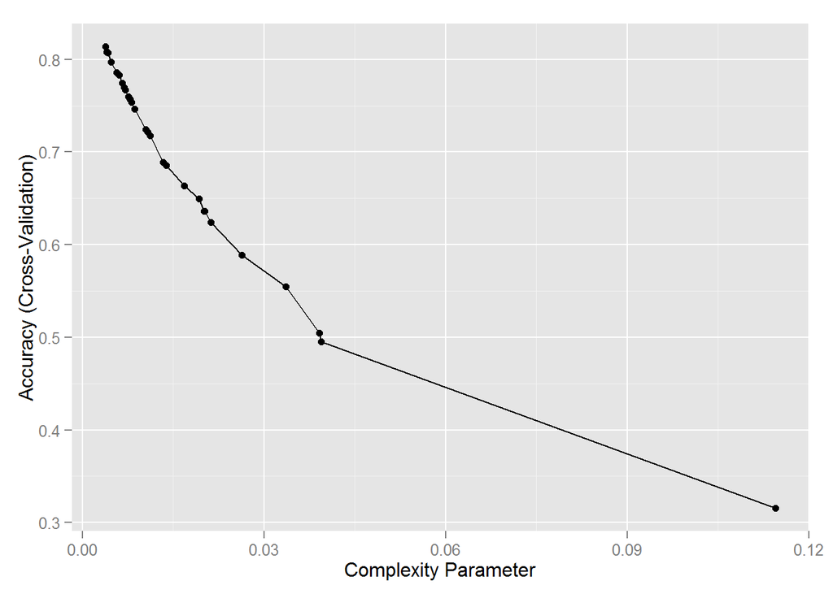

```r
ggplot(modelRpart)
```

The next model tried is the boosted tree model (‘gbm’ method in Caret). This model can be tuned using the number of trees (for boosting) and the depth/complexity of the tree.

```r
gbmGrid <-  expand.grid(interaction.depth = 1:9,
                        n.trees = (2:5)*50,
                        shrinkage = 0.1,
                        n.minobsinnode = 10)
modelGbm <- train(classe ~ ., data = trainTransformed, method = "gbm", trControl = controlFunc, verbose = FALSE, tuneGrid = gbmGrid)
```

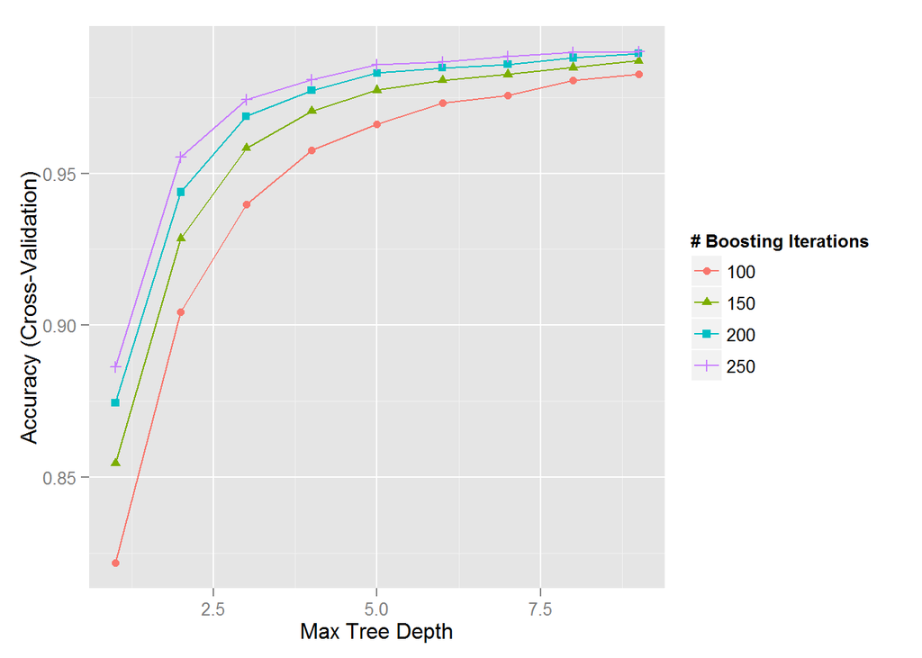

```r
ggplot(modelGbm)
```

As the plot clearly shows that the deeper the tree the better the results. However, it does stabilize at a depth of 7. Same goes for the number of trees used for boosting. At 200 trees the results are good (the model should not be too complicated, to avoid overfitting). Therefore the final model should be with depth 7 and 200 trees, with the following results.

```r
gbmGrid <-  expand.grid(interaction.depth = 7,
                        n.trees = 200,
                        shrinkage = 0.1,
                        n.minobsinnode = 10)
modelGbm <- train(classe ~ ., data = trainTransformed, method = "gbm", trControl = controlFunc, verbose = FALSE, tuneGrid = gbmGrid)
modelGbm
```

```
## Stochastic Gradient Boosting
##
## 11776 samples
##    52 predictor
##     5 classes: 'A', 'B', 'C', 'D', 'E'
##
## No pre-processing
## Resampling: Cross-Validated (5 fold)
## Summary of sample sizes: 9420, 9421, 9420, 9423, 9420
## Resampling results
##
##   Accuracy  Kappa      Accuracy SD  Kappa SD
##   0.985903  0.9821683  0.001395618  0.001763059
##
## Tuning parameter 'n.trees' was held constant at a value of 200
##  7
## Tuning parameter 'shrinkage' was held constant at a value of 0.1
##
## Tuning parameter 'n.minobsinnode' was held constant at a value of 10
##
```

The final model that will be tried is the random forest model.

```r
modelRf <- train(classe ~ ., data = trainTransformed, method = "rf", trControl = controlFunc, tuneLength = 5)
```

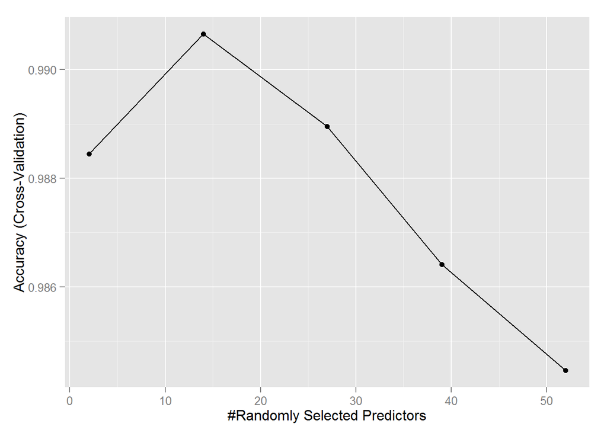

```r
ggplot(modelRf)
```

It shows that the random forest model has the highest accuracy. But it also shows that the estimated accuracy is not really influenced by tuning the parameter. This indicates that the random forests model is better, and most likely more robust. The estimated results for the final model are as follows:

```r
modelRf$finalModel
```

```
##
## Call:
##  randomForest(x = x, y = y, mtry = param$mtry)
##                Type of random forest: classification
##                      Number of trees: 500
## No. of variables tried at each split: 14
##
##         OOB estimate of  error rate: 0.69%
## Confusion matrix:
##      A    B    C    D    E class.error
## A 3344    3    0    0    1 0.001194743
## B   17 2257    5    0    0 0.009653357
## C    0    8 2040    6    0 0.006815969
## D    0    0   25 1902    3 0.014507772
## E    0    0    3   10 2152 0.006004619
```

# Results

To see what the results are for the final chosen model with Random Forest we validate it with the validation set. This is the out of sample test, and gives a more accurate accuracy number, since it is new data to the model. An overfitted model would perform poorly on new data.

```r
validationPredict <- predict(modelRf, validationTransformed[,-53])
confusionMatrix(validationPredict, validationTransformed$classe)
```

```
## Confusion Matrix and Statistics
##
##           Reference
## Prediction    A    B    C    D    E
##          A 2228    7    0    0    0
##          B    4 1506    4    0    0
##          C    0    5 1361   16    3
##          D    0    0    3 1267    5
##          E    0    0    0    3 1434
##
## Overall Statistics
##
##                Accuracy : 0.9936
##                  95% CI : (0.9916, 0.9953)
##     No Information Rate : 0.2845
##     P-Value [Acc > NIR] : < 2.2e-16
##
##                   Kappa : 0.9919
##  Mcnemar's Test P-Value : NA
##
## Statistics by Class:
##
##                      Class: A Class: B Class: C Class: D Class: E
## Sensitivity            0.9982   0.9921   0.9949   0.9852   0.9945
## Specificity            0.9988   0.9987   0.9963   0.9988   0.9995
## Pos Pred Value         0.9969   0.9947   0.9827   0.9937   0.9979
## Neg Pred Value         0.9993   0.9981   0.9989   0.9971   0.9988
## Prevalence             0.2845   0.1935   0.1744   0.1639   0.1838
## Detection Rate         0.2840   0.1919   0.1735   0.1615   0.1828
## Detection Prevalence   0.2849   0.1930   0.1765   0.1625   0.1832
## Balanced Accuracy      0.9985   0.9954   0.9956   0.9920   0.9970
```